# Data Viz

June 8, 2019

## Today's talk

- https://bit.ly/2Wt7nkQ
- Intro
- What is ggplot
- Tips & Tricks
- Best Practices
- Try it out

## An intro

- Jake Riley
- Clinical Data Analyst at Children's Hospital of Philadelphia
- Avid `ggplot2` answerer on stackoverflow
- dogdad

@yake_84

https://bit.ly/2Wt7nkQ

## Before we get started

- this talk is aimed at intermediate `ggplot2` users
- everything is within the `tidyverse` framework & R for Data Science (R4DS)
- the pipe `%>%` is used in many places and allows us to create a sequence of manipulations

`iris %>% arrange(Species)` is the same as `arrange(iris, Species)`

- the `+` used with `ggplot()` is another type of pipe
- you can pipe from a `dplyr` sequence into a `ggplot()` sequence

## What is ggplot?

- grammar of graphics
- just like every sentence has a **subject, verb, and noun**, every chart has a **coordinate system, geom, and aesthetics**
- the hope is that we will invent new types of charts

```r
p <-
  ggplot(mpg) +
  geom_count(
    aes(cty, hwy, color = class),
    alpha = 0.8
  ) +
  theme_bw()
```

## an example

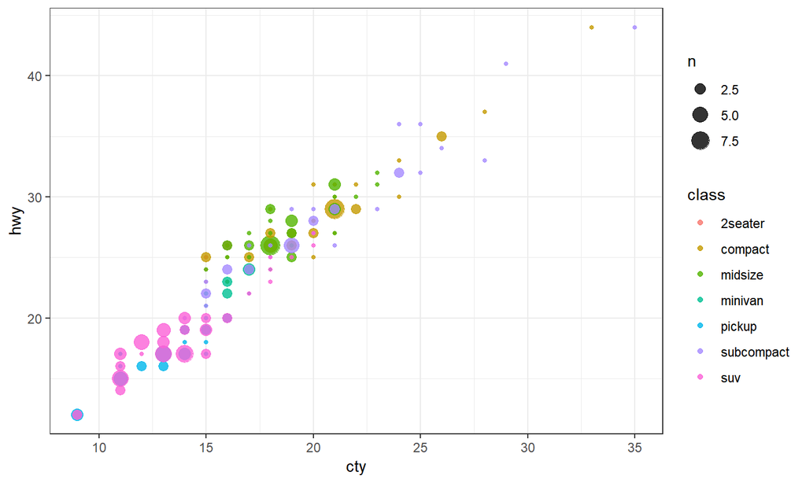

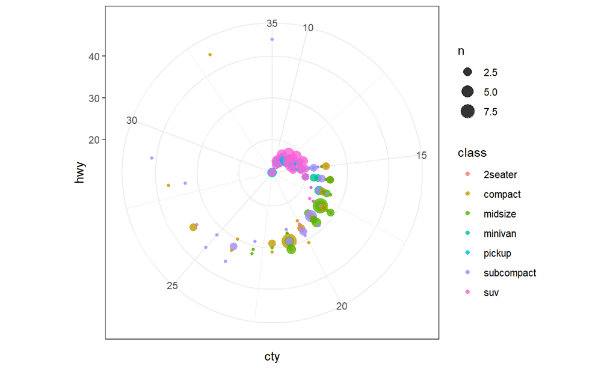

```r
p

p + coord_polar()
```

## Demystifying `aes()`

- `aes()` = aesthetics
- dynamic, data driven **variables** go inside the `aes()`
- constant, static **values** go outside
- the first 2 arguments of `aes()` are `x` and `y` and I will mostly omit naming these

## Note the difference

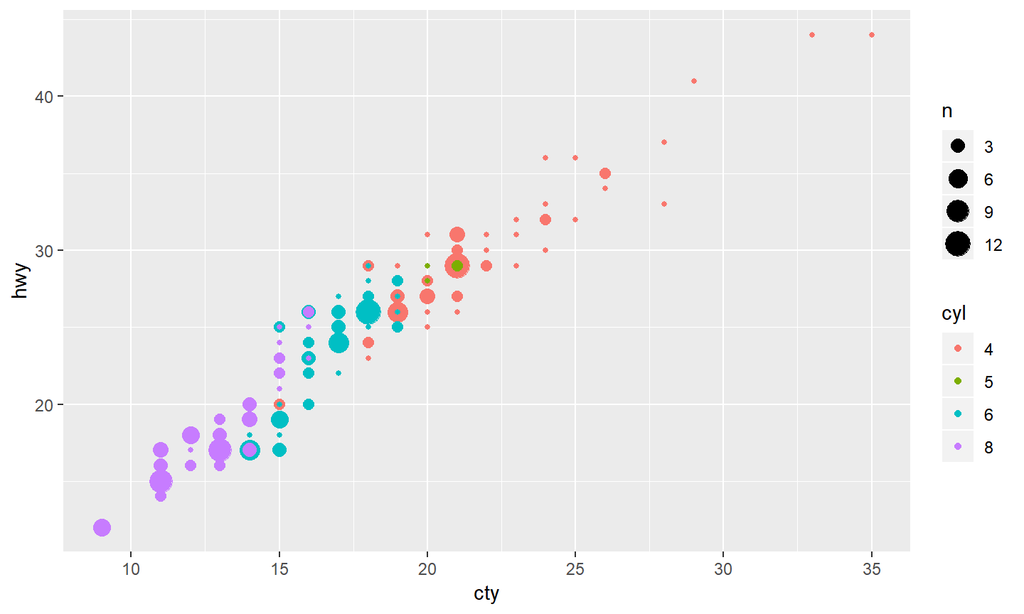

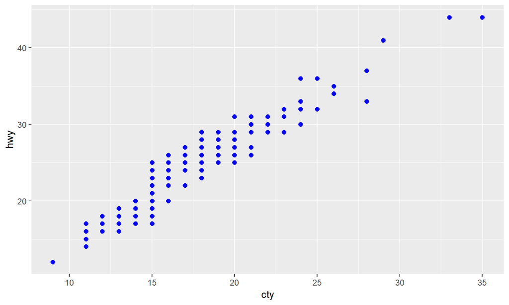

## Tips & Tricks

## Descending bar charts

The number one things I get asked is how to make a barchart go in descending order.

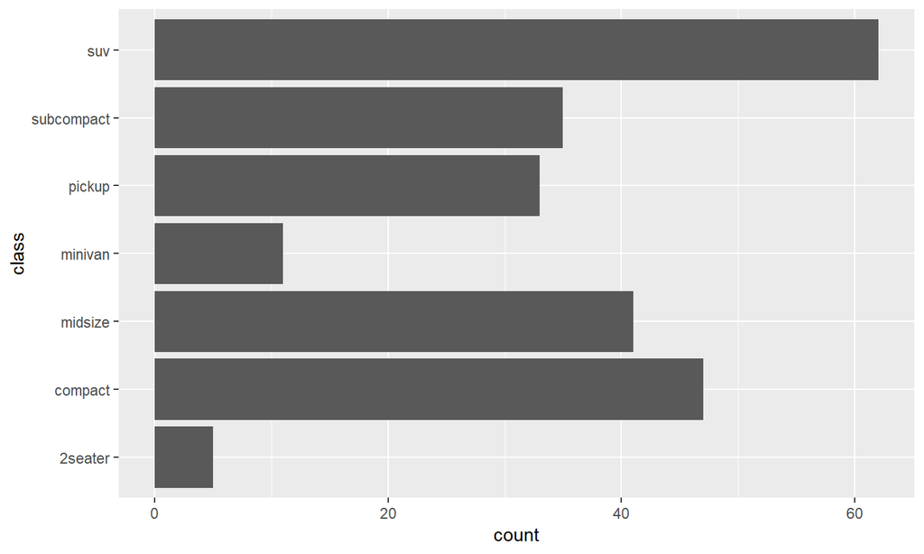

```r
ggplot(mpg, aes(class)) +
  geom_bar() +
  coord_flip()
```

## Arrange by volume: `fct_infreq()`

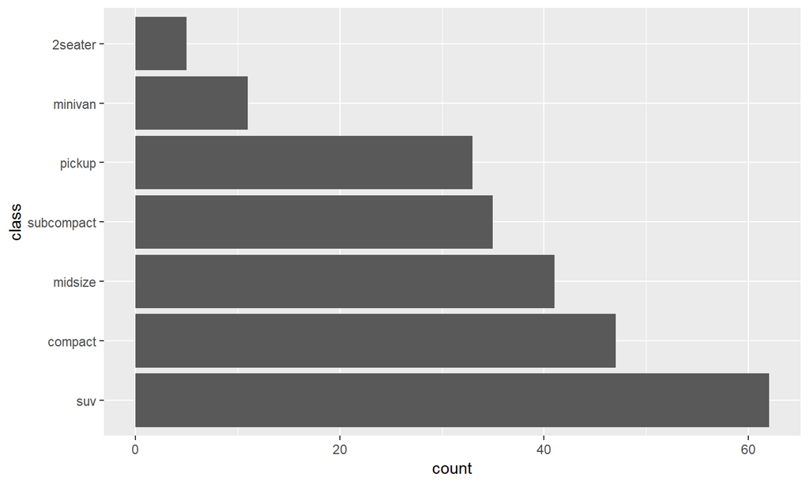

```r
mpg %>%
  mutate(class = fct_infreq(class)) %>%
  ggplot(aes(class)) +
  geom_bar() +
  coord_flip()
```

## Arrange in descending order: `fct_rev()`

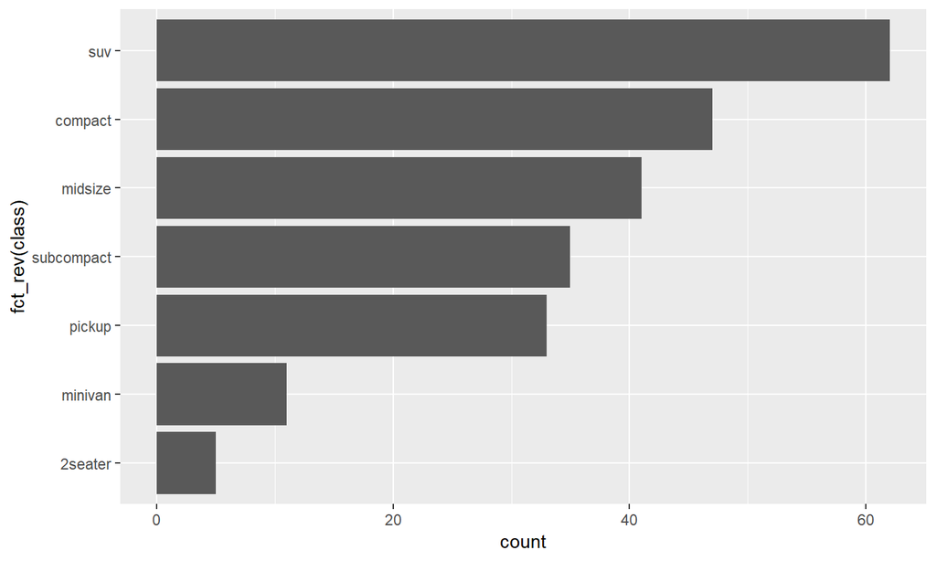

```r
mpg %>%
  mutate(class = fct_infreq(class)) %>%
  ggplot(aes(fct_rev(class))) +
  geom_bar() +
  coord_flip()
```

## Aggregated data: `fct_reorder()`

```r
mpg %>%
  count(class) %>%
  mutate(class = fct_reorder(class, n, sum))
```

```
## # A tibble: 7 x 2
##   class          n
##   <fct>      <int>
## 1 2seater        5
## 2 compact       47
## 3 midsize       41
## 4 minivan       11
## 5 pickup        33
## 6 subcompact    35
## 7 suv           62
```

## Aggregated data: `fct_reorder()`

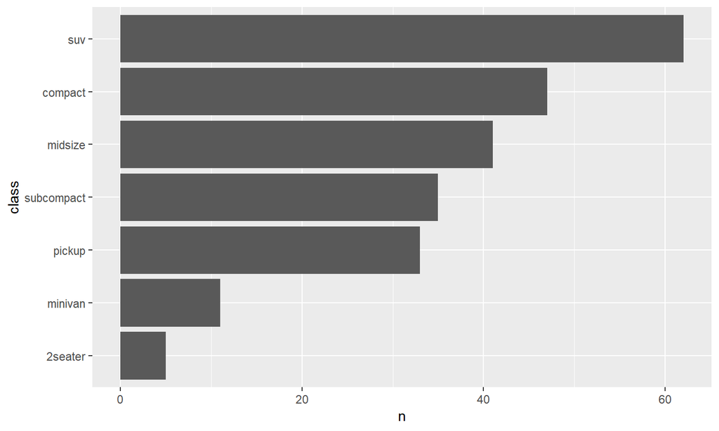

```r
mpg %>%
  count(class) %>%
  mutate(class = fct_reorder(class, n, sum)) %>%
  ggplot(aes(class, n)) +
  geom_col() +
  coord_flip()
```

## Q1: can you put this in descending order?

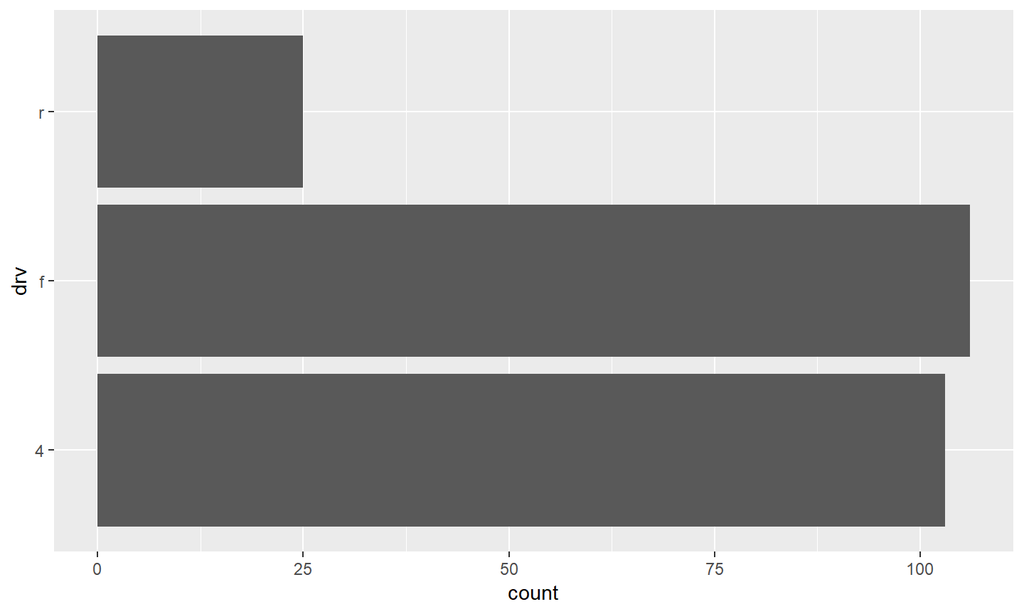

```r
ggplot(mpg, aes(drv)) +
  geom_bar() +
  coord_flip()
```

## Too many bars

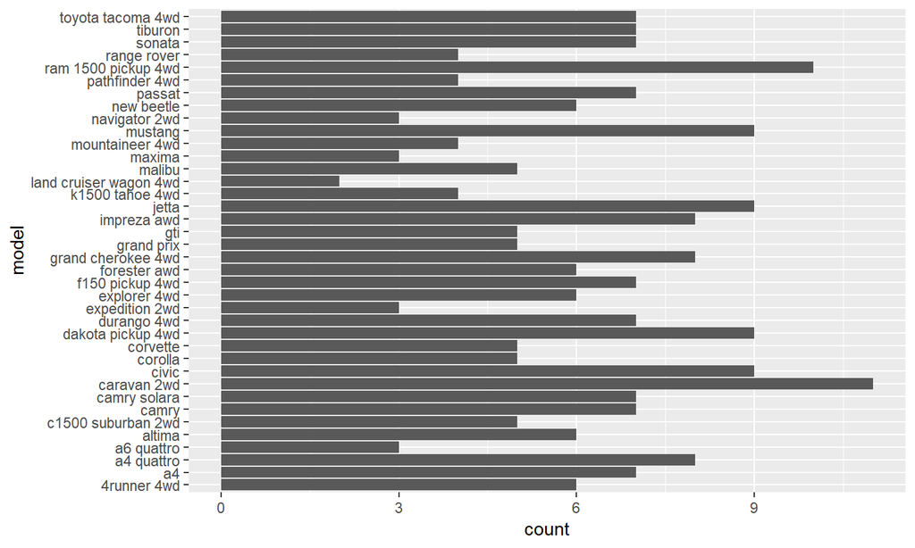

```r
ggplot(mpg, aes(model)) +
  geom_bar() +
  coord_flip()
```

## Too many bars: `fct_lump()`

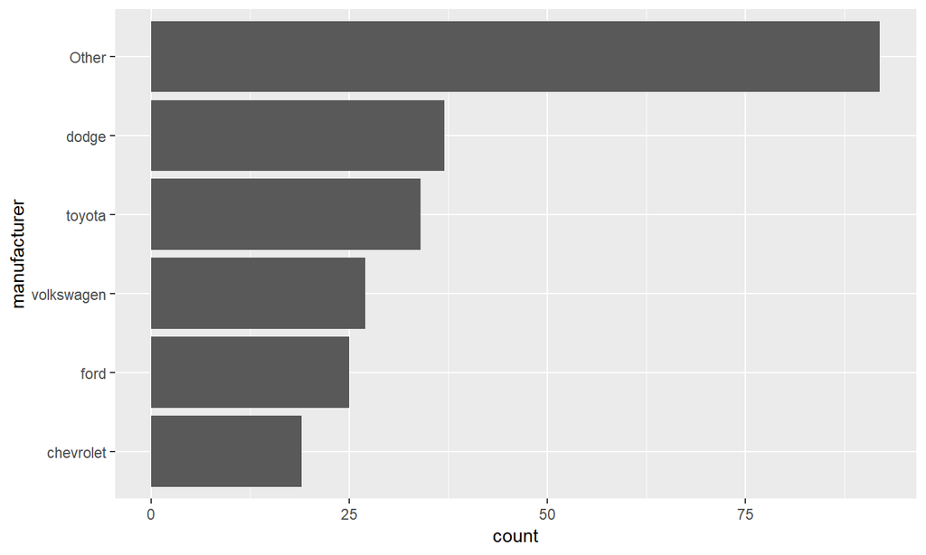

```r
mpg %>%
  mutate(
    manufacturer = fct_lump(manufacturer, 5),
    manufacturer = fct_infreq(manufacturer),
    manufacturer = fct_rev(manufacturer)
  ) %>%
  ggplot(aes(x = manufacturer)) +
  geom_bar() +
  coord_flip()
```

## Order of fill

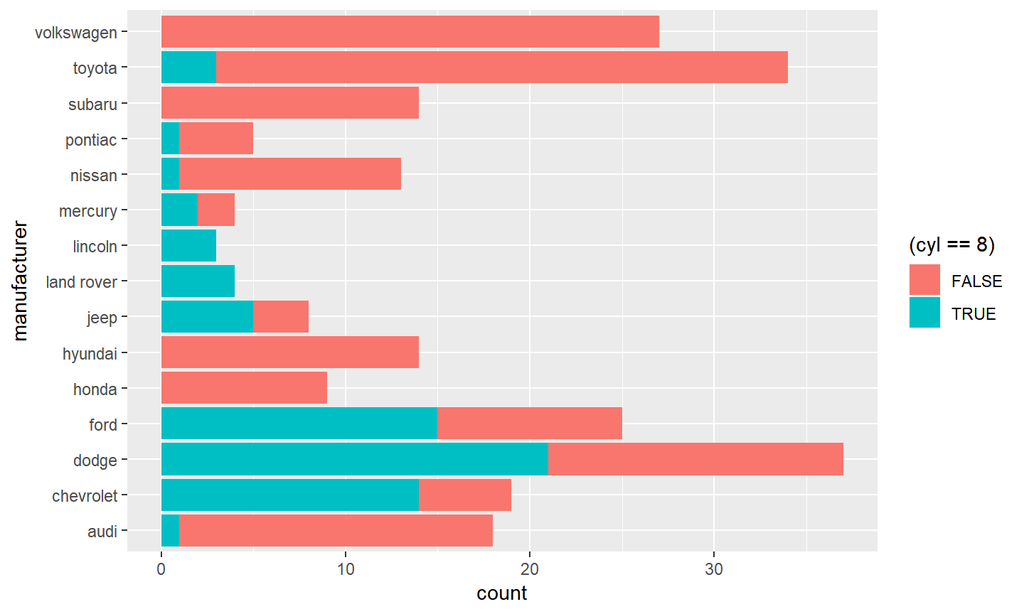

```r
ggplot(mpg, aes(manufacturer, fill = (cyl == 8))) +
  geom_bar() +
  coord_flip()
```

## Order of fill

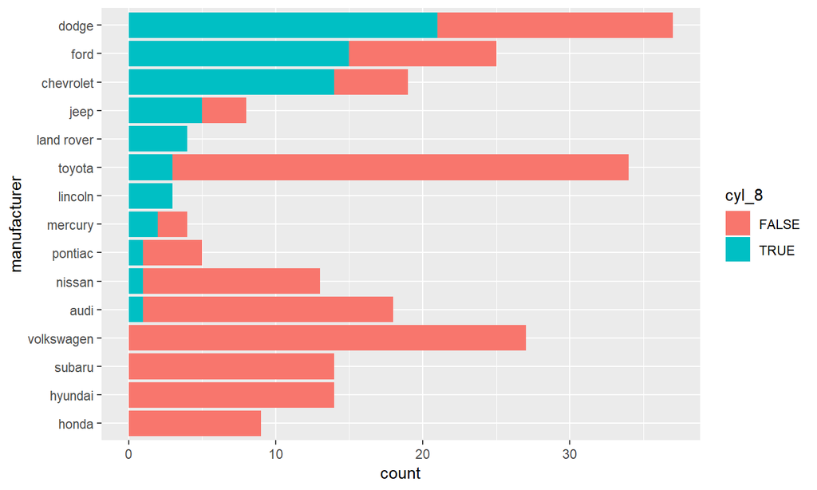

```r
mpg %>%
  mutate(
    cyl_8 = (cyl == 8),
    manufacturer = fct_reorder(manufacturer, cyl_8, sum)
  ) %>%
  ggplot(aes(manufacturer, fill = cyl_8)) +
  geom_bar() +
  coord_flip()
```

## Q2: can you show the manufacturers with the highest proportion *(bonus: can you make it 100% fill?)*

## `facet_grid()` vs `facet_wrap()`

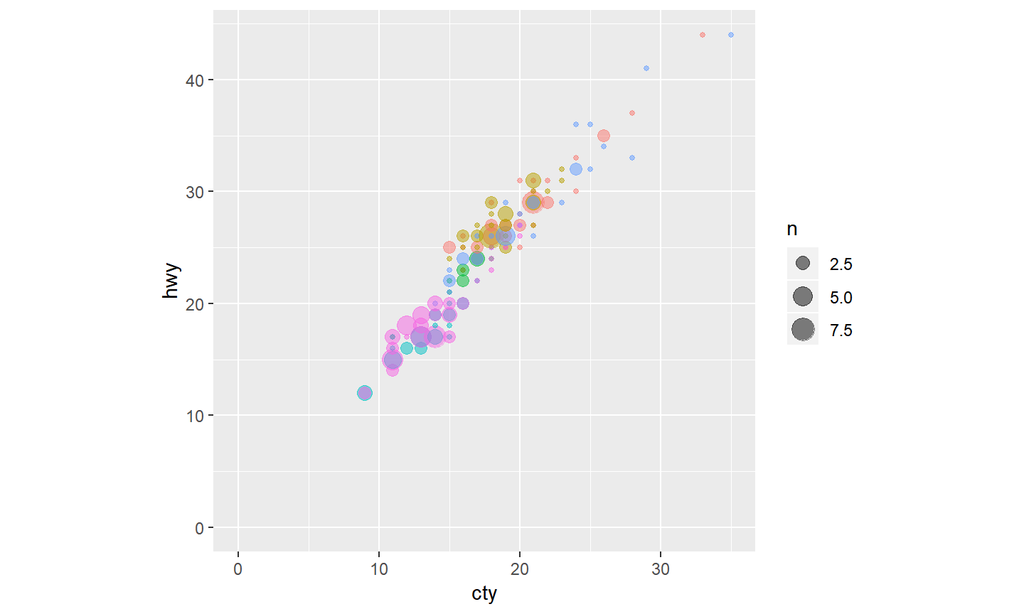

```r
p <-
  mpg %>%
  filter(class != "2seater", cyl != 5) %>%
  ggplot(aes(cty, hwy, color = class)) +
  geom_count(alpha = 0.5) +
  lims(x = c(0, NA), y = c(0, NA)) + # can also use xlim() or scale_x_continuous
  guides(color = FALSE) +
  theme(aspect.ratio = 1)

p
```

## facet_grid: new syntax

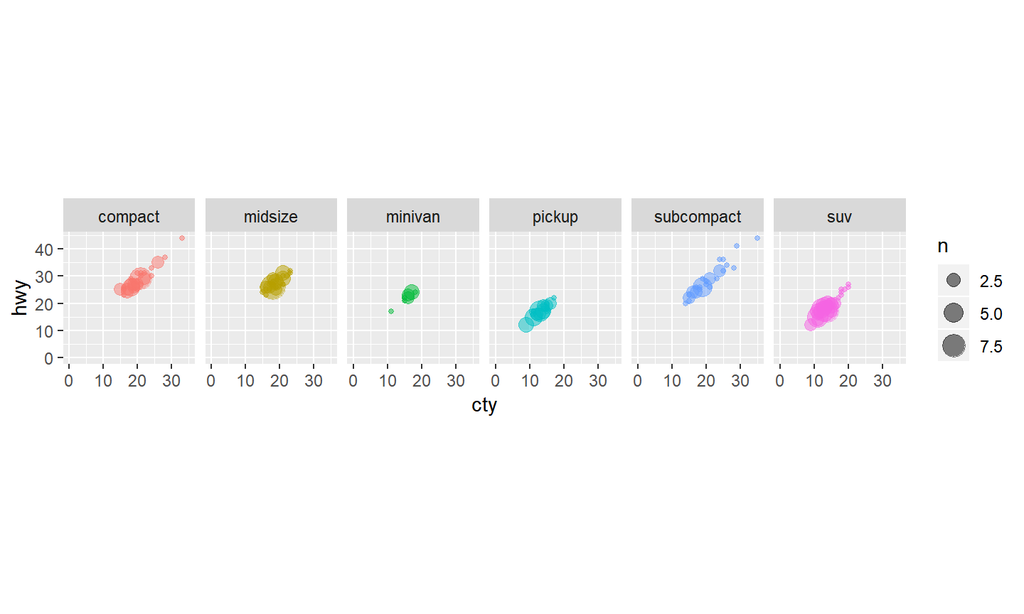

```r
# this is the new syntax, replaces `facet_grid(~class)`
p + facet_grid(cols = vars(class))
```

## facets: scales

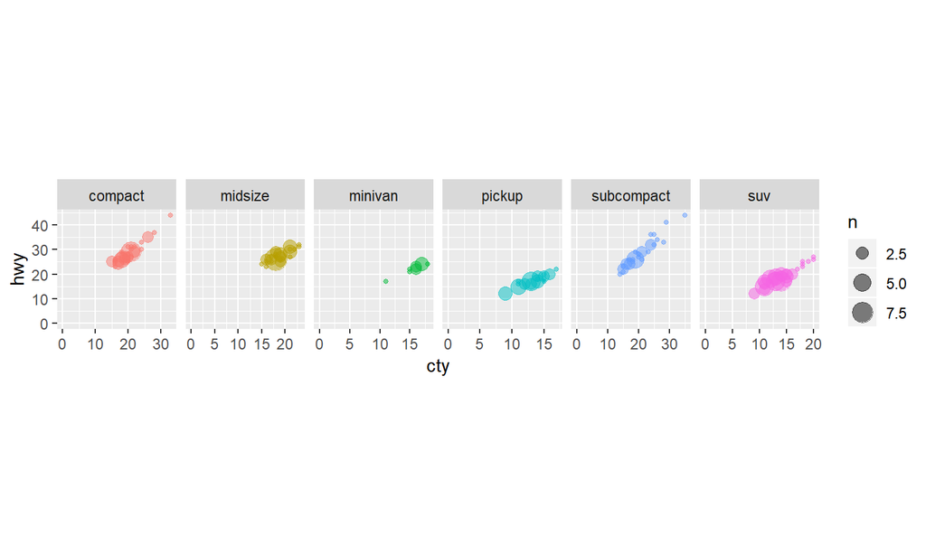

```r
# scales allows the x & y to vary
# also "free_x", "free_y"
p + facet_grid(cols = vars(class), scales = "free")
```

## facets: scales & space

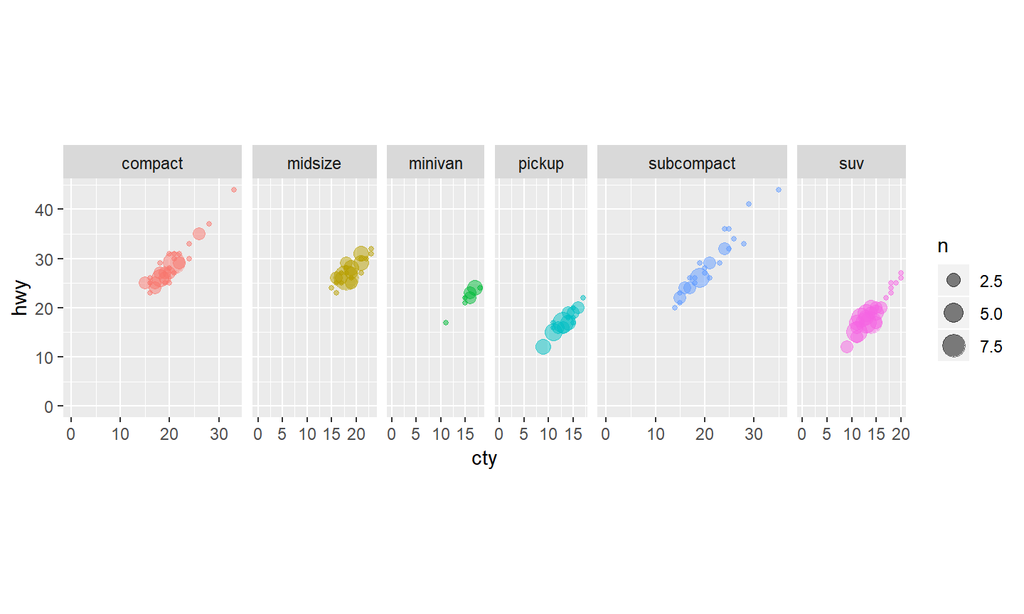

```r
p + facet_grid(cols = vars(class), scales = "free", space = "free")
```

## facets: margins

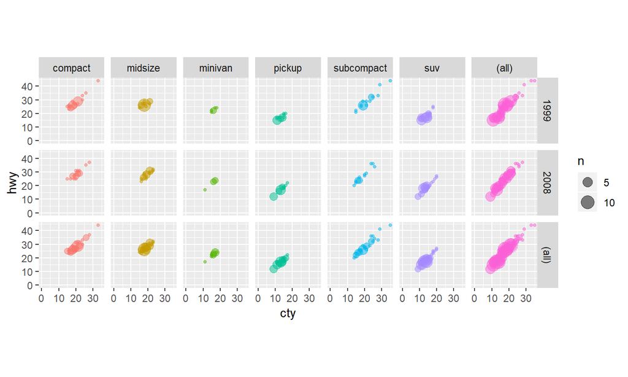

```r
p +
  facet_grid(
    rows = vars(year),
    cols = vars(class),
    margins = TRUE
  )
```

## facet_wrap: # of columns/rows

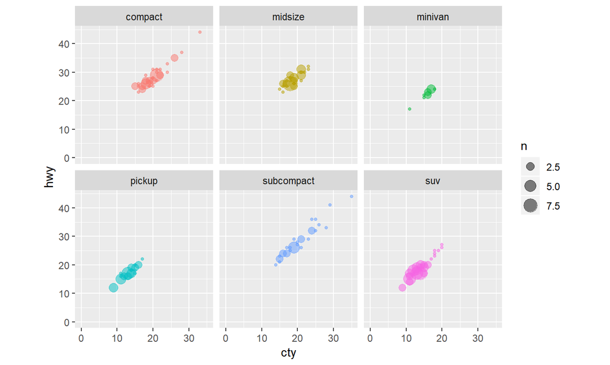

```r
# also nrow
p + facet_wrap(~class, ncol = 3)
```

## facet_wrap: scales

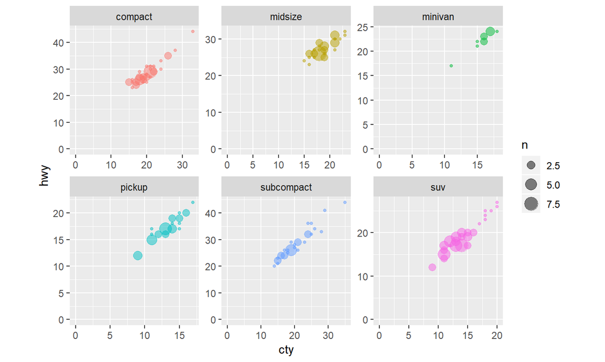

```r
# space does not work with facet_wrap()
p + facet_wrap(~class, ncol = 3, scales = "free")
```

## facets: (a + b)

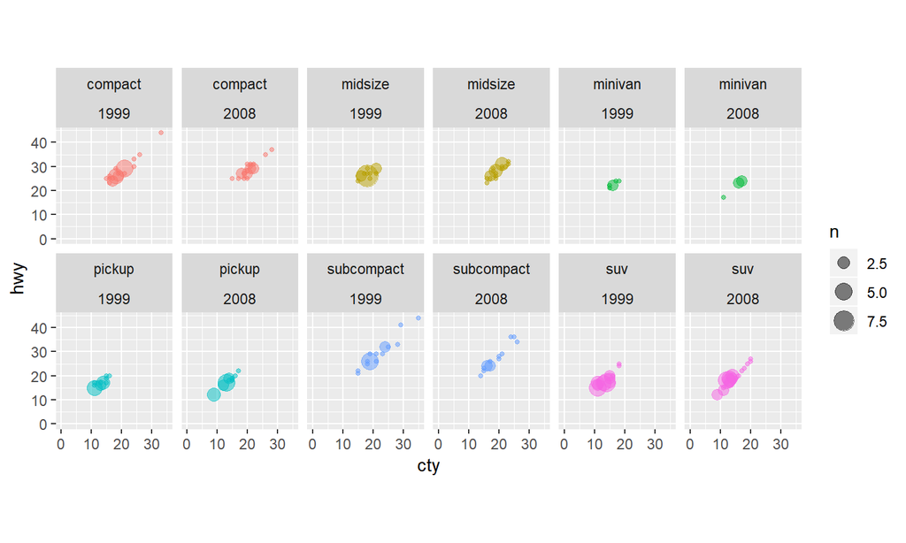

```r
# also works with facet_grid
p + facet_wrap(~class + year, nrow = 2)
```

## `scale_*_identity()`

Sometimes I want to have better control over colors & sizes.

Here, I am hard coding the colors

```r
df <-
  mpg %>%
  mutate(category =
    case_when(
      cty < 14 ~ "coral",
      cty > 19 ~ "turquoise",
      TRUE ~ "grey40"
    )
  )
```

## `scale_color_identity()`

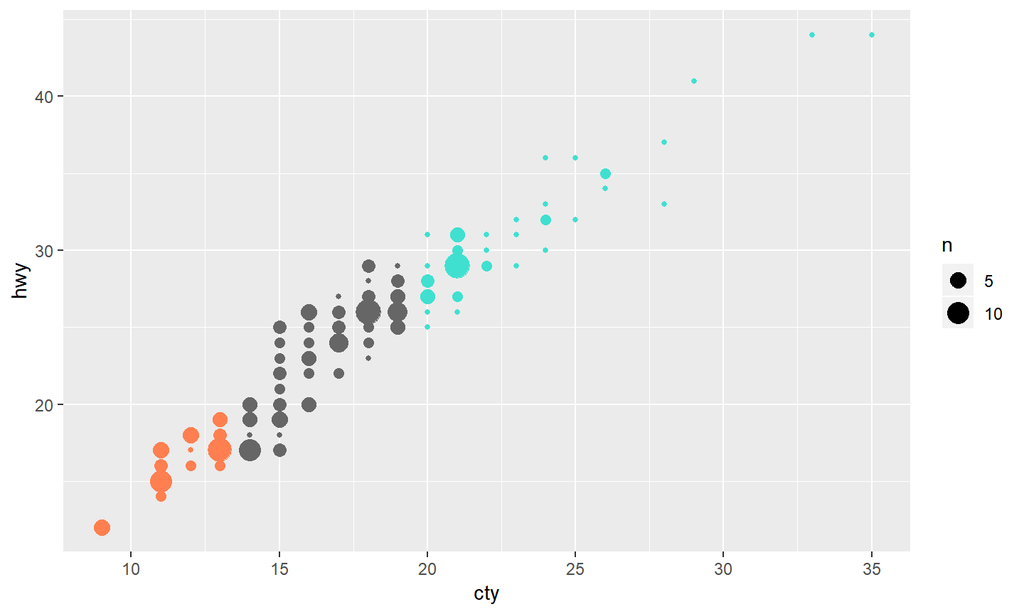

```r
ggplot(df, aes(cty, hwy, color = category)) +
  geom_count() +
  scale_color_identity()
```

## `scale_fill_identity()`

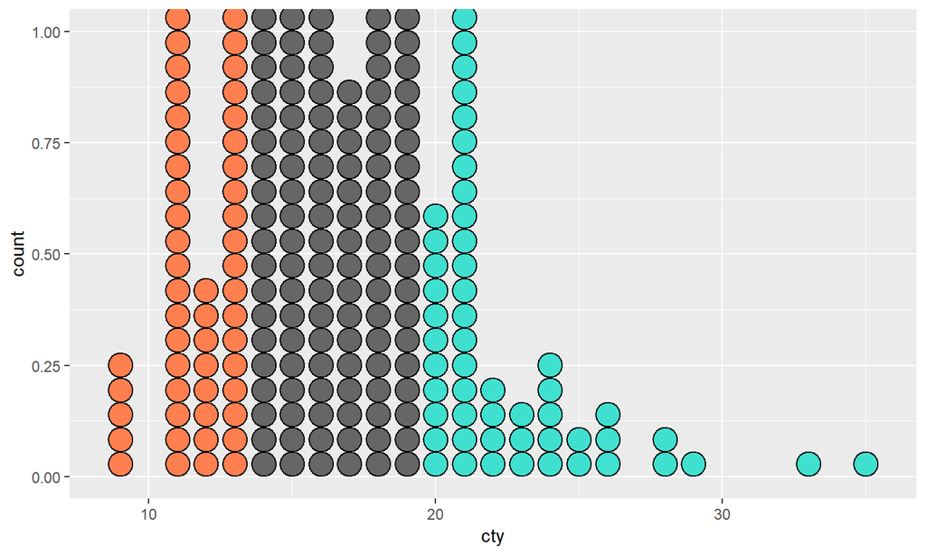

```r
ggplot(df, aes(cty, fill = category)) +
  geom_dotplot() +
  scale_fill_identity()
```

## Best practices

## The golden ratio 1:1.6

- Try to give your charts the proportion of a credit card
- Also look this up

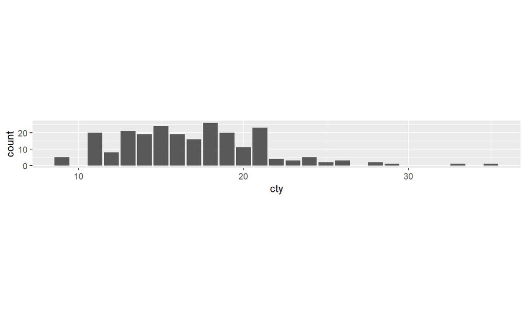

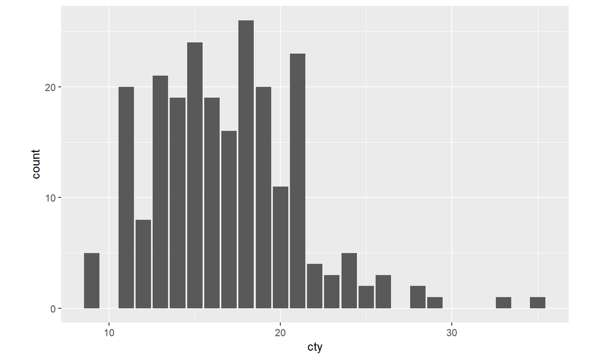

```r
p <- ggplot(mpg, aes(cty)) + geom_bar()

p + coord_fixed(1/10)
p + theme(aspect.ratio = 1/1.6) # ratio depends on the units
```

## Dealing with spaghetti charts

This is one of the most common questions to answer: **change for multiple categories over time**. This often results in a chart like the one below. It is hard to read but there are some ways you can help your audience

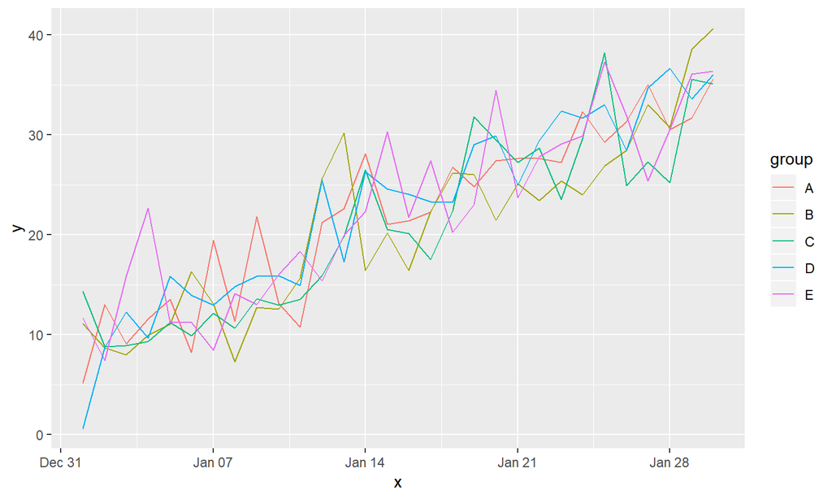

```r
ggplot(df, aes(x, y, color = group)) +
  geom_line()
```

## Highlight the focus & use an informative title

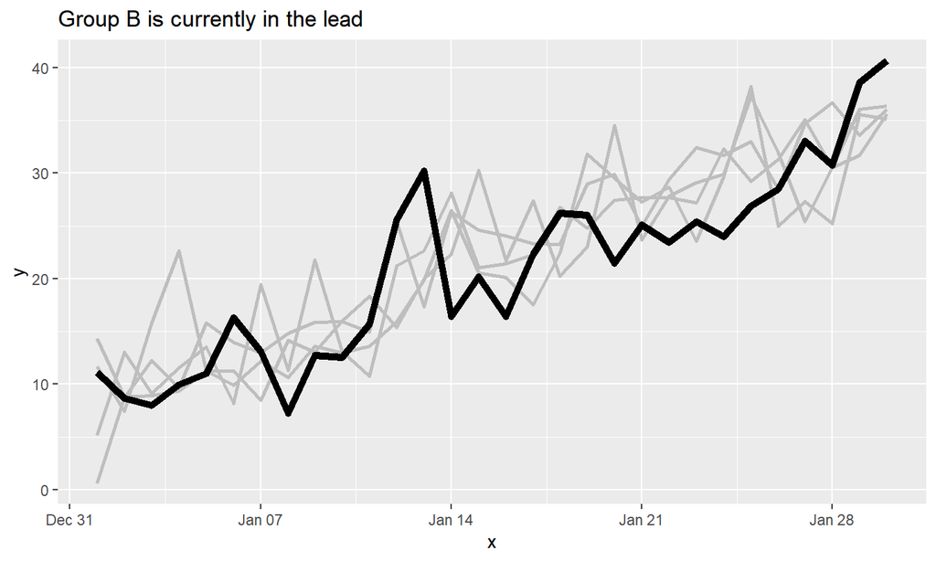

```r
ggplot(df, aes(x, y, group = group)) +
  geom_line(data = filter(df, group != "B"), color = "grey", size = 1) +
  geom_line(data = filter(df, group == "B"), color = "black", size = 2) +
  labs(title = "Group B is currently in the lead")
```

## Try a heatmap but beware

[colorblind palette viewer](https://davidmathlogic.com/colorblind/#%2334804B-%236FD46B-%23D5D6D6-%23E5E6E6-%23B53D13)

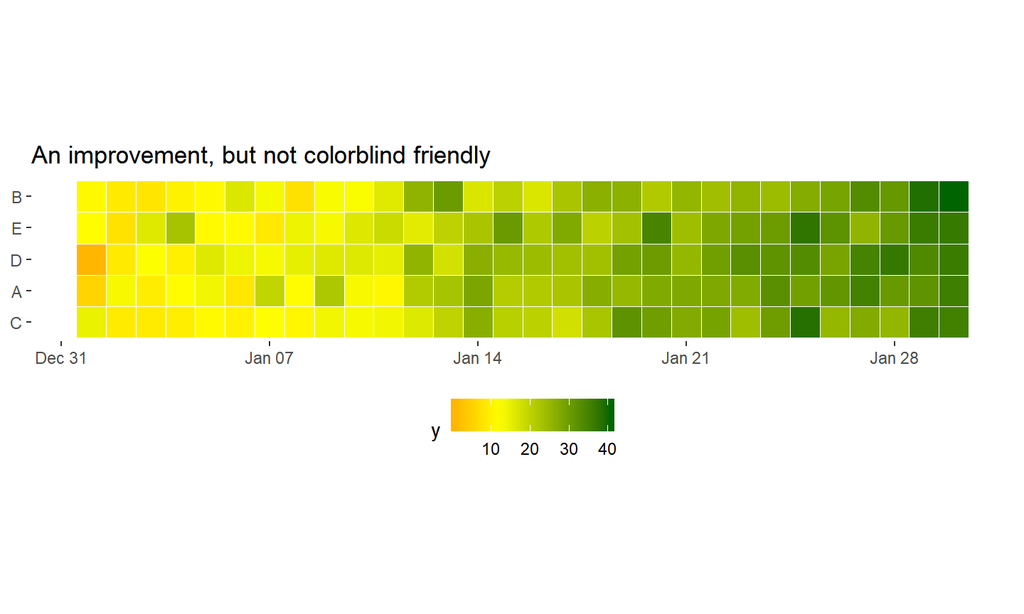

```r
ggplot(df, aes(x, fct_reorder(group, y, last), fill = y)) +
  geom_tile(color = "white") +
  scale_fill_gradient2(
    low = "red", mid = "yellow", high = "darkgreen", midpoint = 12
  ) +
  my_theme +
  labs(title = "An improvement, but not colorblind friendly")
```

## Not every point needs a color

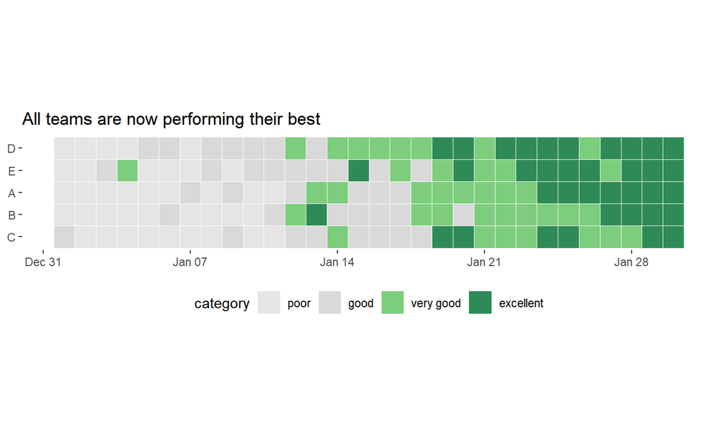

```r
ggplot(df, aes(x, fct_reorder(group, y), fill = category)) +
  geom_tile(color = "white", size = 0.1) +
  scale_fill_manual(
    values = c("grey90", "grey85", "palegreen3", "seagreen4"),
    labels = c("poor", "good", "very good", "excellent")
  ) +
  my_theme +
  labs(title = "All teams are now performing their best")
```

## Partner activity: Extensions & Addins

## Partner activity

- left side: focus on extensions
- right side: focus on add-ins
- bonus: my `simplecolors` package
- with your partner, review the code and resources below
- find a function or feature that you think is interesting or useful
- place screenshots here https://bit.ly/2XiG5C7
- you don't need to run the code, you can use images from the vignettes
- we'll share at the end

## Extensions & Addins

- [ggplot extensions](https://www.ggplot2-exts.org/ggiraph.html)
- [ggplot addins](https://github.com/daattali/addinslist)

## Extensions

- [ggradar - spider/radar plots](https://github.com/ricardo-bion/ggradar)
- [gganimate](https://gganimate.com/)
- [ggrepel](https://cran.r-project.org/web/packages/ggrepel/vignettes/ggrepel.html)
- [ggforce](https://cran.rstudio.com/web/packages/ggforce/vignettes/Visual_Guide.html)
- [cowplot](https://cran.r-project.org/web/packages/cowplot/vignettes/introduction.html)
- [more](https://www.ggplot2-exts.org/ggiraph.html)

## `addinslist`:

`addinslist::addinslistAddin()`

```r
# install.packages("addinslist")
# install.packages("esquisse")
# install.packages("ggedit")
# install.packages("ggThemeAssist")
# install.packages("colourpicker")

data(iris)
data(mpg)

p <-
  ggplot(mpg, aes(cty, hwy)) +
  geom_point()
```

## Addins in action

```r
# esquisse
  esquisse:::esquisser()
  esquisse:::esquisser(mpg)

# others
  ggThemeAssist::ggThemeAssistGadget(p)
  ggedit(p)
  colourpicker::colourPicker()
```

## `simplecolors`

https://rjake.github.io/simplecolors/articles/intro.html

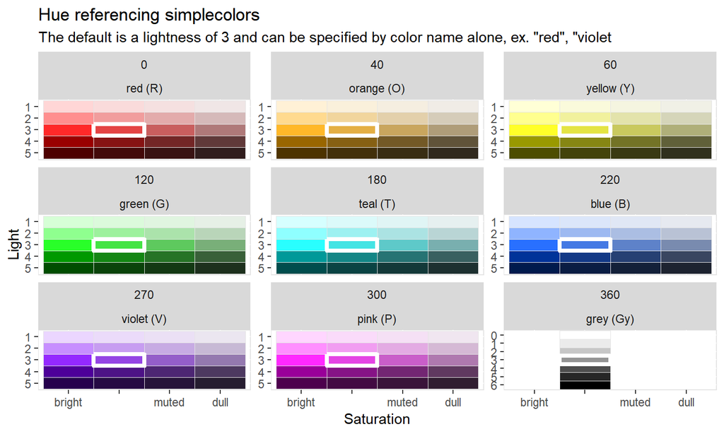

```r
#devtools::install_github("rjake/simplecolors")
library(simplecolors)
simplecolors::show_colors(labels = FALSE)
```

## `simplecolors`

Three main functions:

`sc()` `sc_across()` `sc_*()`

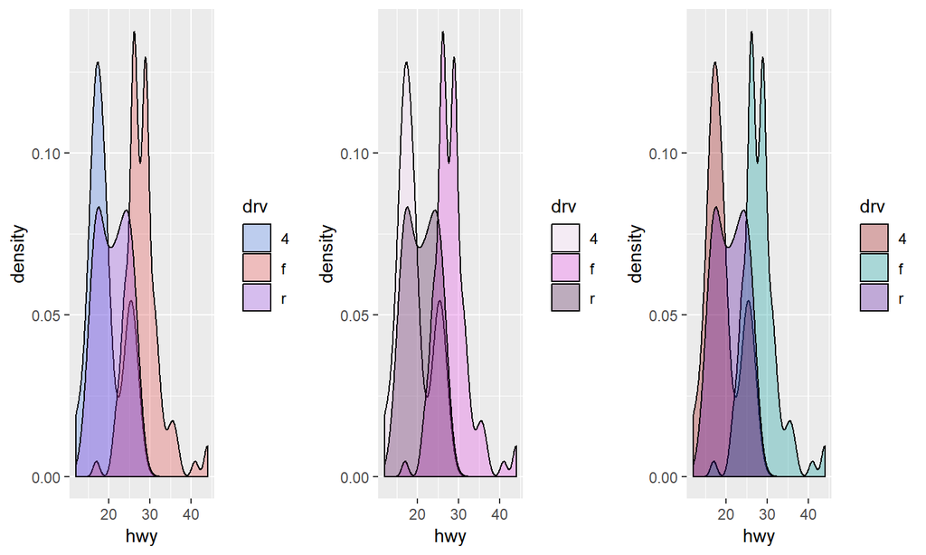

```r
p <-
  ggplot(mpg, aes(hwy, fill = drv)) +
  geom_density(alpha = 0.3)

p + scale_fill_manual(values = sc("blue3", "red3", "violet3"))
p + scale_fill_manual(values = sc_pink(light = c(1,3,5)))
p + scale_fill_manual(values = sc_across("RTV", light = 4, sat = "bright"))
```

## Appendix

## R4DS

R for Data Science is a book all about the `tidyverse`. It is less "data science-y" and more about data manipulation and visualization. It is free online [here](https://r4ds.had.co.nz/) as well as available for sale.

## Stackoverflow

- try `datapasta` for a minimal reprex
- include images
- incorporate `styler`

## Cheatsheet

https://github.com/rstudio/cheatsheets/raw/master/data-visualization-2.1.pdf

## Take care when cropping data

The usual methods to "zoom in" can yield unexpected results when stat_ geoms are used. For example, `geom_boxplot()` calls `stat_boxplot()` and filters out data **before** doing the stats and your boxplot will keep readjusting the quartiles

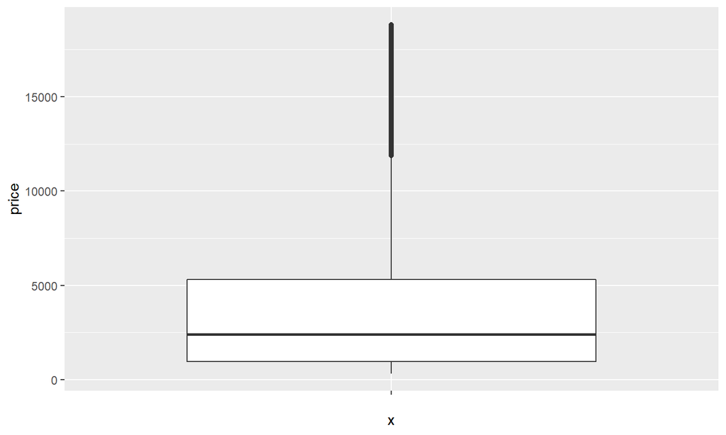